# Newton's Laws of Motion

In the lectures up till now we have been discussing kinematics, the description of motion. Now we start to explore the dynamics of motion, introducing the key concept of force and Newton's Laws of Motion.

[figure not shown]

Godfrey Kneller's 1689 portrait of Isaac Newton (From Wikipedia).

### May the force be with you

What is a force? In a somewhat circular definition, a force is something that when applied to an object can cause it to change it's motion. As we'll see however it is the **sum** of forces on an object that actually determines it's motion.

Force is a vector, and so those sums will be vector sums!

### Newton's First Law of Motion

Is motion of an object fundamentally different to it being at rest? Our experience with reference frames should tell us otherwise. An object with a constant velocity in one reference frame would be at rest in a reference frame which had the same constant velocity as the object. It follows then that motion with a constant velocity is not intrinsically different to an object being at rest. This idea, which begins with Galileo, is the basis for Newton's first law of motion.

**Every object continues in its state of rest, or of uniform velocity in a straight line, as long as no net force acts on it.**

This law essentially describes the property of an object that we call **inertia**.

### Conceptual Example 4-1: Newton’s first law.

A school bus comes to a sudden stop, and all of the backpacks on the floor start to slide forward. What force causes them to do that?

### Forces are vectors

[figure not shown]

### Inertial Reference Frames

Newton's first law only applies in inertial reference frames, which are frames which are not accelerating. Bear in mind that acceleration can mean change of direction as well as magnitude of velocity, so rotating reference frame is not an inertial frame.

In fact, although we usually treat it as one, the Earth is not an inertial reference frame, as it is rotating. The effect of the Earth's rotation on a moving object over time can be measured using a [Foucalt Pendulum](https://www.animations.physics.unsw.edu.au/jw/foucault_pendulum.html)

### Newton's Second Law of Motion

How much inertia does an object have? This is determined by it's mass, for which the SI unit is kg. The more mass an object has the harder it is to get it to change it's motion.

For an object to change it's velocity and thus have an acceleration, it needs to be subjected to a net force. The degree of acceleration produced by the sum of the forces is determined by the size of the force and the mass of the object according to the formula.

$\sum\vec{F}=m\vec{a}$

Dimensional analysis shows us that force must have units kgms$^{-2}$. These units are normally expressed as Newtons and denoted by the symbol N.

### Hammer demo

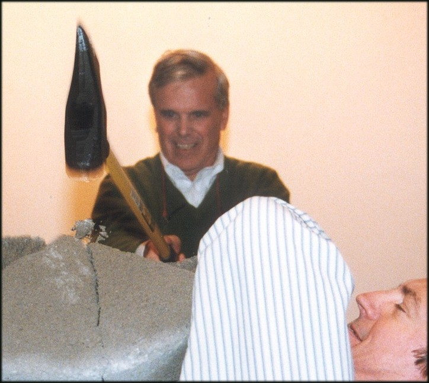

### Newton's Third Law of Motion

Whenever one object exerts a force on a second object, the second exerts an equal force in the opposite direction on the first.

Another way of saying this: Forces come in action-reaction pairs and the sum of the forces in a pair is zero.

Be careful with the third law, the equal and opposite forces are acting on different objects. The motion of an object is determined only by the sum of the forces acting on that object.

### Action and Reaction in Time

Horizontal forces only!

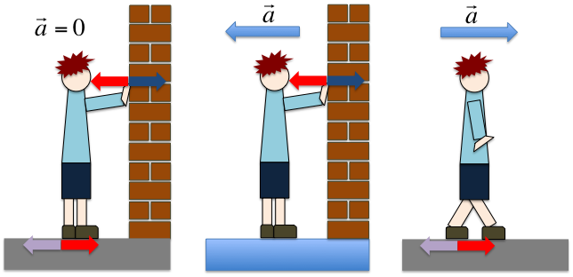

### Weight

All objects on Earth (or near to it) are constantly subjected to gravitational force. The weight of an object is equal to the force which acts on it due to gravity.

As we established earlier that all objects in free fall have acceleration $\vec{g} = 9.81 ms^{-2}$ it follows from the second law that the force due to gravity on an object is

$\vec{F}_g=m\vec{g}$

Each object subject to gravitational force exerts an equal and opposite force on the Earth to the one it exerts on us. However the Earth's mass is quite large!

### Normal force

When an object is supported by a surface it is subject to a force that we call the normal force. In the case where the gravitational force is the only other force acting on the object and the surface is flat with respect to the surface of the Earth the normal force is equal and opposite to the gravitational force. This is not a result of the 3rd law, the diagram below shows the right way to think about the various action and reaction pairs.

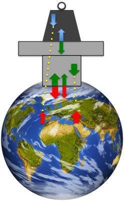

### Weight on a scale in an elevator

When you stand on a scale it claims to measure your mass in kg or lbs. In fact it is measuring the force exerted on it (equal and opposite to the normal force it exerts), assuming that this is your weight and then showing the value of weight divided by the acceleration due to gravity.

As you can see the normal force on an object is only equal to the gravitational force when there is no other force on the object. If you stand on a set of scales in an elevator your apparent mass as displayed by the scale will thus be affected by the acceleration of the lift.

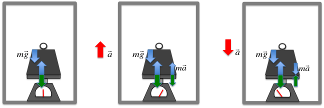

### Tension in ropes

Frequently in physics problems you will see ropes, strings, cords, wires, etc. Typically they are assumed to be mass-less. This means that the net force on any section of a rope when extended is considered to be zero independent of the acceleration of the rope ($\sum\vec{F}=ma$ with *m*=0), allowing a perfect transmission of force from one end of the rope to another. The force transmitted from one end of the rope to the other is the tension in the rope, and it should be noted that all real ropes have a maximum tension above which they break.

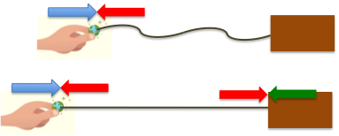

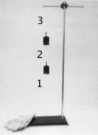

### Free-body diagrams

In our next lecture we will apply these concepts to a number of situations. In each case we will be drawing **free-body diagrams**. The diagrams are used to represent all the forces on an object to determine the net force on it. They are termed fee-body diagrams because each diagram considers only the forces acting on the particular object considered.

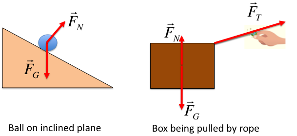

### Approach

- Resolve force vectors in to appropriate components - often requires trigonometry.
- Find sum of force components.
- If necessary convert back to resultant net force vector.

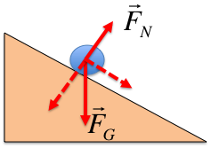

Conceptual Example 4-10: The hockey puck. A hockey puck is sliding at constant velocity across a flat horizontal ice surface that is assumed to be frictionless. Which of these sketches is the correct free-body diagram for this puck? What would your answer be if the puck slowed down?

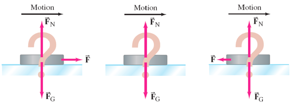